# Udacity Machine Learning NanoDegree Capstone Project

# ============================================================

# Set Phasers to Stun - Train SVC to 110 component PCA with GridSearch for Optimized parameters.

It's clear that SVC has some big accuracy advantages over Naive Bayes. Therefore I'm going after this one.

```python
pca_110 = PCA(n_components = 110, whiten=True)
pca_110.fit(X_train)

# C and gamma parameter rangers
C_range = np.logspace(0, 3, 4)
gamma_range = np.logspace(-3, 1, 5)

parameter_grid = {'gamma': gamma_range, 'C': C_range}
scorer = make_scorer(accuracy_score)
svc = SVC()
clf = GridSearchCV(svc, parameter_grid, scoring=scorer)

clf.fit(pca_110.transform(X_train), y_train.activity.values)
```

```
GridSearchCV(cv='warn', error_score='raise-deprecating',
             estimator=SVC(C=1.0, cache_size=200, class_weight=None, coef0=0.0,
                           decision_function_shape='ovr', degree=3,
                           gamma='auto_deprecated', kernel='rbf', max_iter=-1,
                           probability=False, random_state=None, shrinking=True,
                           tol=0.001, verbose=False),
             iid='warn', n_jobs=None,
             param_grid={'C': array([   1.,   10.,  100., 1000.]),
                         'gamma': array([1.e-03, 1.e-02, 1.e-01, 1.e+00, 1.e+01])},
             pre_dispatch='2*n_jobs', refit=True, return_train_score=False,
             scoring=make_scorer(accuracy_score), verbose=0)
```

```python
print(clf.best_estimator_)
print('')
print(clf.best_params_)
print('')
print(clf.best_score_)
```

```
SVC(C=100.0, cache_size=200, class_weight=None, coef0=0.0,
    decision_function_shape='ovr', degree=3, gamma=0.001, kernel='rbf',
    max_iter=-1, probability=False, random_state=None, shrinking=True,
    tol=0.001, verbose=False)

{'C': 100.0, 'gamma': 0.001}

0.9219775975280031
```

```python
clf_svc_tuned = clf.best_estimator_
pca_110_clf_svc_tuned_train_time = train_classifier(clf_svc_tuned,
                                                    pca_110.transform(X_train),
                                                    y_train.activity.values)
print(clf_svc_tuned)
```

```
Training SVC...
Done!
Training time (secs): 2.553
SVC(C=100.0, cache_size=200, class_weight=None, coef0=0.0,
    decision_function_shape='ovr', degree=3, gamma=0.001, kernel='rbf',
    max_iter=-1, probability=False, random_state=None, shrinking=True,
    tol=0.001, verbose=False)
```

```python
# Training metrics SVC
pca_110_train_output_svc_tuned = predict_labels(clf_svc_tuned, pca_110.transform(X_train), y_train)
print ("Accuracy score for training set: {}".format(pca_110_train_output_svc_tuned[0]))
print ("F1 score for training set:       {}".format(pca_110_train_output_svc_tuned[1]))

# whitespace
print('')
print('')
# Testing metrics SVC
pca_110_test_output_svc_tuned = predict_labels(clf_svc_tuned, pca_110.transform(X_test), y_test, False)
print ("Accuracy score for Testing set: {:.10f}".format(pca_110_test_output_svc_tuned[0]))
print ("F1 score for Testing set:       {:.10f}".format(pca_110_test_output_svc_tuned[1]))
```

```
Predicting labels for Training Set using SVC...
Done!
Prediction time for Training Set (secs): 3.535
Accuracy score for training set: 0.9988412514484357
F1 score for training set:       0.9988413114282713


Predicting labels for Testing Set using SVC...
Done!
Prediction time for Testing Set (secs): 1.446
Accuracy score for Testing set: 0.9427577483
F1 score for Testing set:       0.9423382832
```

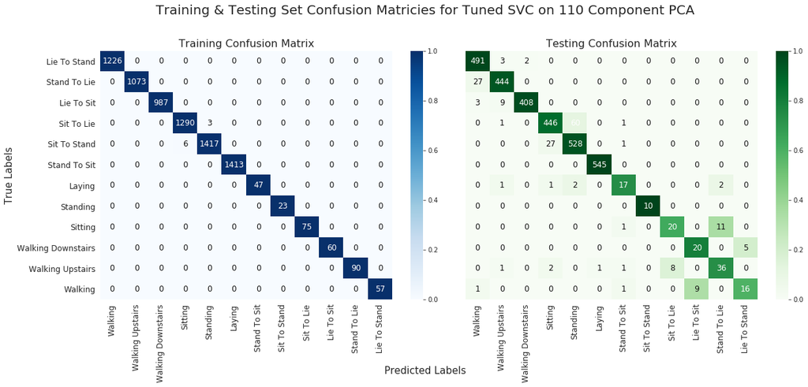

```python
# Plotting SVC Testing CMs
title = 'Training & Testing Set Confusion Matricies for Tuned SVC on 110 Component PCA'
questionable_annot_colors = ([str(pca_110_train_output_svc_tuned[2][x, x]) for x in range(12)] +
                             [str(pca_110_test_output_svc_tuned[2][x, x]) for x in range(12)])
plot_confusion_matricies(pca_110_train_output_svc_tuned[2],
                         pca_110_test_output_svc_tuned[2],
                         title, questionable_annot_colors)
```

## Testing on the Tuned SVC on the Entire Featurespace

```python
full_clf_svc_tuned_train_time = train_classifier(clf_svc_tuned, X_train, y_train.activity.values)
print(clf_svc_tuned)
```

```
Training SVC...
Done!
Training time (secs): 3.644
SVC(C=100.0, cache_size=200, class_weight=None, coef0=0.0,
    decision_function_shape='ovr', degree=3, gamma=0.001, kernel='rbf',
    max_iter=-1, probability=False, random_state=None, shrinking=True,
    tol=0.001, verbose=False)
```

```python
# Training metrics SVC entire dataset
train_output_svc_tuned = predict_labels(clf_svc_tuned, X_train, y_train)
print ("Accuracy score for training set: {}".format(train_output_svc_tuned[0]))
print ("F1 score for training set:       {}".format(train_output_svc_tuned[1]))

# whitespace
print('')
print('')

# Testing metrics SVC
test_output_svc_tuned = predict_labels(clf_svc_tuned, X_test, y_test, False)
print ("Accuracy score for Testing set: {:.10f}".format(test_output_svc_tuned[0]))
print ("F1 score for Testing set:       {:.10f}".format(test_output_svc_tuned[1]))
```

```
Predicting labels for Training Set using SVC...
Done!
Prediction time for Training Set (secs): 7.444
Accuracy score for training set: 0.991373760782799
F1 score for training set:       0.9913744418050583


Predicting labels for Testing Set using SVC...
Done!
Prediction time for Testing Set (secs): 3.099
Accuracy score for Testing set: 0.9535104364
F1 score for Testing set:       0.9532493847
```

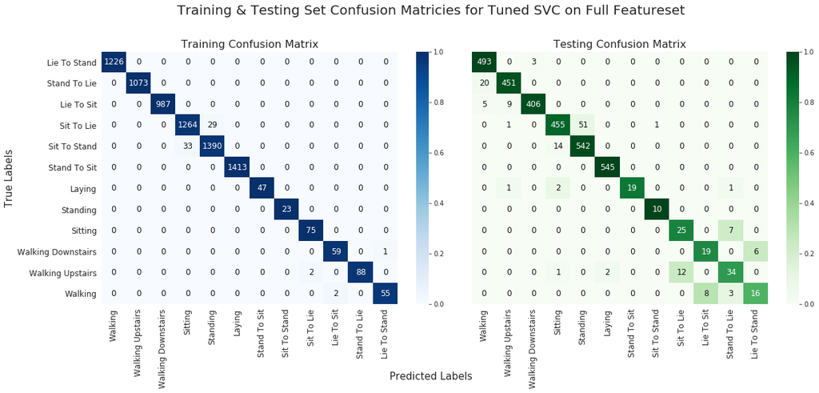

```python
# Plotting SVC Testing CMs
title = 'Training & Testing Set Confusion Matricies for Tuned SVC on Full Featureset'
questionable_annot_colors = ([str(train_output_svc_tuned[2][x, x]) for x in range(12)] +
                             [str(test_output_svc_tuned[2][x, x]) for x in range(12)])
plot_confusion_matricies(train_output_svc_tuned[2],
                         test_output_svc_tuned[2],
                         title, questionable_annot_colors)
```

### Accuracies vs Times Plot for final mold on PCA vs Entire Featureset

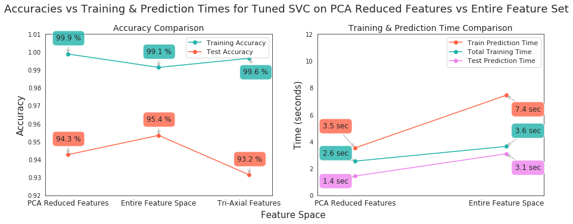

```python
# setup figure with side by side plot
fig, axes = plt.subplots(nrows=1, ncols=2, sharey=False, sharex=False)
fig.set_size_inches(15, 5) # Plot figure Size

# setup accuracy and time lists
training_accuracies = [pca_110_train_output_svc_tuned[0],
                      train_output_svc_tuned[0],
                      0.996466431095]
testing_accuracies = [pca_110_test_output_svc_tuned[0],
                     test_output_svc_tuned[0],
                     0.9315068493]

training_times = [pca_110_clf_svc_tuned_train_time,
                 full_clf_svc_tuned_train_time]
train_pred_times = [pca_110_train_output_svc_tuned[3],
                   train_output_svc_tuned[3]]
test_pred_times = [pca_110_test_output_svc_tuned[3],
                  test_output_svc_tuned[3]]

plt.suptitle('Accuracies vs Training & Prediction Times for Tuned SVC on PCA Reduced Features vs Entire Feature Set',
             y=1.02, fontsize=18)

axes[0].plot([0, 1, 2], training_accuracies, '-o', color='lightseagreen', label='Training Accuracy')
axes[0].plot([0, 1, 2], testing_accuracies, '-o', color='tomato', label='Test Accuracy')
axes[1].plot(train_pred_times, '-o', color='tomato', label='Train Prediction Time')
axes[1].plot(training_times, '-o', color='lightseagreen', label='Total Training Time')
axes[1].plot(test_pred_times, '-o', color='violet', label='Test Prediction Time')

# set axis ranges and titles
axes[0].set_ylim(0.92, 1.01)
axes[0].set_xlim(-0.25, 2.25)
axes[1].set_ylim(0, 12)
axes[1].set_xlim(-0.25, 1.25)
axes[0].set_xticks([0, 1, 2])
axes[0].set_xticklabels(['PCA Reduced Features', 'Entire Feature Space', 'Tri-Axial Features'], fontsize=12)
axes[0].set_ylabel('Accuracy', fontsize=15)
axes[1].set_ylabel('Time (seconds)', fontsize=15)
axes[1].set_xticks([0, 1])
axes[1].set_xticklabels(['PCA Reduced Features', 'Entire Feature Space'], fontsize=12)
fig.text(0.51, 0.02, 'Feature Space', ha='center', fontsize=15)
axes[0].set_title('Accuracy Comparison', fontsize=14)
axes[1].set_title('Training & Prediction Time Comparison', fontsize=14)

# annotations
def annotate_point(ax, point, points, loc=(-20, 20), color='lightseagreen', accuracy=True):
    axes[ax].annotate('{:.1f} {}'.format(points[point] * 100 if accuracy else points[point],
                                        '%' if accuracy else 'sec'),
            xy = (point, points[point]), xytext = loc,
            textcoords = 'offset points', ha = 'left', va = 'bottom', fontsize=12,
            bbox = dict(boxstyle = 'round,pad=0.5', fc = color, alpha = 0.8),
            arrowprops = dict(arrowstyle = '->', connectionstyle = 'arc3, rad=0', linewidth=1, color='darkgrey'))

annotate_point(0, 0, training_accuracies)
annotate_point(0, 1, training_accuracies)
annotate_point(0, 2, training_accuracies, loc=(-10, -30))
annotate_point(0, 0, testing_accuracies, color='tomato')
annotate_point(0, 1, testing_accuracies, color='tomato')
annotate_point(0, 2, testing_accuracies, color='tomato')
annotate_point(1, 0, training_times, loc=(-54, 7), accuracy=False)
annotate_point(1, 1, training_times, loc=(15, 20), accuracy=False)
annotate_point(1, 0, train_pred_times, loc=(-54, 30), color='tomato', accuracy=False)
annotate_point(1, 1, train_pred_times, loc=(15, -30), color='tomato', accuracy=False)
annotate_point(1, 0, test_pred_times, loc=(-54, -15), color='violet', accuracy=False)
annotate_point(1, 1, test_pred_times, loc=(15, -30), color='violet', accuracy=False)

axes[0].legend(fontsize=11)
axes[1].legend(fontsize=11)
plt.show()
```

# ============================================================

# Machine Learning on RAW Triaxial Gyroscope and Accelerometer Data

For comparison it was decided to create my own simplified feature vectors from the original RAW data to see how it compares to the performance of the PCA reduction and the entire feature space.

### y_raw DataFrame creation

```python
y_raw = pd.read_csv('/content/drive/My Drive/Colab Notebooks/hapt-data/RawData/labels.txt', sep=' ', header=None)

# Column 1: experiment number ID,
# Column 2: user number ID,
# Column 3: activity number ID
# Column 4: Label start point (in number of signal log samples (recorded at 50Hz))
# Column 5: Label end point (in number of signal log samples)
y_raw.columns = ['Experiment_ID', 'User_ID', 'Activity_ID', 'Start_Point', 'End_Point']
y_raw[y_raw['Experiment_ID'] == 1].head()
```

|  | Experiment_ID | User_ID | Activity_ID | Start_Point | End_Point |
| --- | --- | --- | --- | --- | --- |
| 0 | 1 | 1 | 5 | 250 | 1232 |
| 1 | 1 | 1 | 7 | 1233 | 1392 |
| 2 | 1 | 1 | 4 | 1393 | 2194 |
| 3 | 1 | 1 | 8 | 2195 | 2359 |
| 4 | 1 | 1 | 5 | 2360 | 3374 |

### X_raw DataFrame creation

```python
import os

# start with empty dataframes
X_acc_raw = pd.DataFrame()
X_gyro_raw = pd.DataFrame()
!ls
# cycle through files to build the X_Raw_dataframe
for raw_file in os.listdir('/content/drive/My Drive/Colab Notebooks/hapt-data/RawData/'):
    if raw_file != 'labels.txt': # ignore labels

        # create a dataframe from the file
        file_frame = pd.read_csv(('/content/drive/My Drive/Colab Notebooks/hapt-data/RawData/' + raw_file), sep=' ', header=None)

        # need to add the experiment ID and user ID to the dataframe
        x = list(filter(str.isdigit, raw_file))
        # x = ["0", "1", "2"]
        y = ''.join(x) # converting list into string
        numbers = y
        exp_ID = int(numbers[1]) if numbers[0] == '0' else int(numbers[0:2])
        user_ID = int(numbers[-1]) if numbers[2] == '0' else int(numbers[2:-1])

        # add experiment ID and user ID columns
        file_frame['Experiment_ID'] = exp_ID
        file_frame['User_ID'] = user_ID

        # setup columns and append to appropriate dataframe
        if raw_file.startswith('acc'):
            file_frame = file_frame.rename(
                columns = {0: 'tRawAcc-1', 1: 'tRawAcc-2', 2: 'tRawAcc-3'})
            X_acc_raw = X_acc_raw.append(file_frame)
        else:
            file_frame = file_frame.rename(
                columns = {0: 'tRawGyro-1', 1: 'tRawGyro-2', 2: 'tRawGyro-3'})
            X_gyro_raw = X_gyro_raw.append(file_frame)

print (len(X_acc_raw))
print (X_acc_raw.head())
print ('')
print(len(X_gyro_raw))
print (X_gyro_raw.head())
```

```
adc.json  drive  sample_data
1122772
   tRawAcc-1  tRawAcc-2  tRawAcc-3  Experiment_ID  User_ID
0   0.188889  -0.016667   1.019445             34        1
1   0.188889  -0.016667   1.019445             34        1
2   0.229167  -0.022222   1.031945             34        1
3   0.238889  -0.027778   1.013889             34        1
4   0.219444  -0.015278   0.972222             34        1

1122772
   tRawGyro-1  tRawGyro-2  tRawGyro-3  Experiment_ID  User_ID
0   -0.286801   -0.304211    0.070555             48        2
1   -0.194866   -0.497550    0.081856             48        2
2   -0.145386   -0.623388    0.082161             48        2
3   -0.093768   -0.717461    0.081856             48        2
4   -0.095295   -0.274889    0.022602             48        2
```

```python
# Import PyDrive and associated libraries.
# This only needs to be done once per notebook.
from pydrive.auth import GoogleAuth
from pydrive.drive import GoogleDrive
from google.colab import auth
from oauth2client.client import GoogleCredentials

# Authenticate and create the PyDrive client.
# This only needs to be done once per notebook.
auth.authenticate_user()
gauth = GoogleAuth()
gauth.credentials = GoogleCredentials.get_application_default()
drive = GoogleDrive(gauth)

# List .txt files in the root.
#
# Search query reference:
# https://developers.google.com/drive/v2/web/search-parameters
listed = drive.ListFile({'q': "title contains '.txt' and 'root' in parents"}).GetList()
for file in listed:
  print('title {}, id {}'.format(file['title'], file['id']))
```

```
title https://oladblo.txt, id 1AskatAUkL4xHGXy3soyUm4tIG_F5U6xT
```

### Understanding Start and Stop Points

The Start and Stop point are the rows in each experiment file that correspond to the Activity ID that's being performed that particular moment. In order to verify this is the case a series of start and stop points were plotted over a section of one of the experiment signals

```python
# the start point and end point correspond to when the user does the specific activity.
y_raw[(y_raw['Experiment_ID'] == 1) & (y_raw['User_ID'] == 1) & (y_raw['Start_Point'] >= 8000)].head()
```

|  | Experiment_ID | User_ID | Activity_ID | Start_Point | End_Point |
| --- | --- | --- | --- | --- | --- |
| 13 | 1 | 1 | 1 | 8356 | 9250 |
| 14 | 1 | 1 | 1 | 9657 | 10567 |
| 15 | 1 | 1 | 1 | 10750 | 11714 |
| 16 | 1 | 1 | 3 | 13191 | 13846 |
| 17 | 1 | 1 | 2 | 14069 | 14699 |

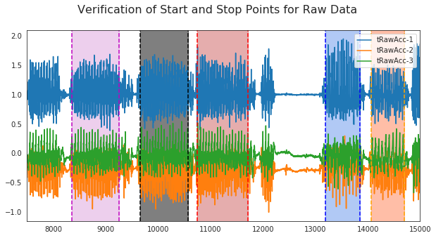

```python
X_acc_raw[(X_acc_raw['Experiment_ID'] == 1) & (X_acc_raw['User_ID'] == 1)][
    ['tRawAcc-1', 'tRawAcc-2', 'tRawAcc-3']][7500:15000].plot(figsize=(10, 5))

plt.suptitle('Verification of Start and Stop Points for Raw Data', fontsize=16)

# check to see if start and stop points align with increased activity
# values are taken from the dataframe.head above
plt.axvline(8356, color='m', linestyle='dashed')
plt.axvline(9250, color='m', linestyle='dashed')
plt.axvspan(8356, 9250, alpha=0.5, color='plum')

plt.axvline(9657, color='k', linestyle='dashed')
plt.axvline(10567, color='k', linestyle='dashed')
plt.axvspan(9657, 10567, alpha=0.5, color='black')

plt.axvline(10750, color='r', linestyle='dashed')
plt.axvline(11714, color='r', linestyle='dashed')
plt.axvspan(10750, 11714, alpha=0.5, color='indianred')

plt.axvline(13191, color='b', linestyle='dashed')
plt.axvline(13846, color='b', linestyle='dashed')
plt.axvspan(13191, 13846, alpha=0.5, color='cornflowerblue')

plt.axvline(14069, color='orange', linestyle='dashed')
plt.axvline(14699, color='orange', linestyle='dashed')
plt.axvspan(14069, 14699, alpha=0.5, color='coral')

plt.show()
```

```python
# build the new data frame
# Starting with Min, Max & Mean
X_processed = pd.DataFrame()

for index, row in y_raw.iterrows():
    row_list = []
    X_acc_activity = X_acc_raw[X_acc_raw['Experiment_ID'] == row['Experiment_ID']][row['Start_Point']:row['End_Point']]
    X_gyro_activity = X_gyro_raw[X_gyro_raw['Experiment_ID'] == row['Experiment_ID']][row['Start_Point']:row['End_Point']]

    row_list.append([X_acc_activity['tRawAcc-1'].mean(),
                     X_acc_activity['tRawAcc-2'].mean(),
                     X_acc_activity['tRawAcc-3'].mean(),
                     X_acc_activity['tRawAcc-1'].min(),
                     X_acc_activity['tRawAcc-2'].min(),
                     X_acc_activity['tRawAcc-3'].min(),
                     X_acc_activity['tRawAcc-1'].max(),
                     X_acc_activity['tRawAcc-2'].max(),
                     X_acc_activity['tRawAcc-3'].max(),
                     X_gyro_activity['tRawGyro-1'].mean(),
                     X_gyro_activity['tRawGyro-2'].mean(),
                     X_gyro_activity['tRawGyro-3'].mean(),
                     X_gyro_activity['tRawGyro-1'].min(),
                     X_gyro_activity['tRawGyro-2'].min(),
                     X_gyro_activity['tRawGyro-3'].min(),
                     X_gyro_activity['tRawGyro-1'].max(),
                     X_gyro_activity['tRawGyro-2'].max(),
                     X_gyro_activity['tRawGyro-3'].max()])
    X_processed = X_processed.append(row_list)

X_processed.columns = ['tRawAcc-Mean-1', 'tRawAcc-Mean-2', 'tRawAcc-Mean-3',
                      'tRawAcc-Min-1', 'tRawAcc-Min-2', 'tRawAcc-Min-3',
                      'tRawAcc-Max-1', 'tRawAcc-Max-2', 'tRawAcc-Max-3',
                      'tRawGyro-Mean-1', 'tRawGyro-Mean-2', 'tRawGyro-Mean-3',
                      'tRawGyro-Min-1', 'tRawGyro-Min-2', 'tRawGyro-Min-3',
                      'tRawGyro-Max-1', 'tRawGyro-Max-2', 'tRawGyro-Max-3']
X_processed.reset_index(drop=True, inplace=True)

print ('The X dataframe contains      {} rows'.format(len(X_processed)))
print ('The Target dataframe contains {} rows'.format(len(y_raw)))
X_processed.head()
```

```
The X dataframe contains      1214 rows
The Target dataframe contains 1214 rows
```

|  | tRawAcc-Mean-1 | tRawAcc-Mean-2 | tRawAcc-Mean-3 | tRawAcc-Min-1 | tRawAcc-Min-2 | tRawAcc-Min-3 | tRawAcc-Max-1 | tRawAcc-Max-2 | tRawAcc-Max-3 | tRawGyro-Mean-1 | tRawGyro-Mean-2 | tRawGyro-Mean-3 | tRawGyro-Min-1 | tRawGyro-Min-2 | tRawGyro-Min-3 | tRawGyro-Max-1 | tRawGyro-Max-2 | tRawGyro-Max-3 |
| --- | --- | --- | --- | --- | --- | --- | --- | --- | --- | --- | --- | --- | --- | --- | --- | --- | --- | --- |
| 0 | 1.020468 | -0.130783 | 0.083431 | 1.009722 | -0.154167 | 0.058333 | 1.030556 | -0.108333 | 0.109722 | 0.005114 | -0.001756 | 0.002741 | -0.034819 | -0.037874 | -0.041233 | 0.059254 | 0.076664 | 0.036346 |
| 1 | 0.990898 | -0.123908 | 0.152455 | 0.780556 | -0.405556 | -0.101389 | 1.219444 | 0.183333 | 0.405556 | 0.066703 | 0.109268 | -0.076635 | -0.777937 | -0.493885 | -0.865291 | 0.757778 | 0.719294 | 0.573297 |
| 2 | 0.834622 | 0.333510 | 0.422885 | 0.681944 | 0.138889 | 0.152778 | 1.062500 | 0.470833 | 0.568056 | 0.008828 | 0.006208 | -0.012846 | -0.726319 | -0.835053 | -0.600481 | 0.556498 | 1.128574 | 0.502131 |
| 3 | 0.944089 | -0.087830 | 0.135281 | 0.741667 | -0.422222 | -0.163889 | 1.347222 | 0.456944 | 0.526389 | -0.056498 | -0.170821 | 0.211654 | -0.833526 | -1.160033 | -0.391565 | 0.394314 | 0.430660 | 1.931250 |
| 4 | 1.008583 | -0.248658 | -0.020422 | 0.759722 | -0.619444 | -0.293056 | 1.244445 | -0.125000 | 0.136111 | 0.073883 | -0.029104 | 0.013909 | -0.620334 | -1.373836 | -0.238237 | 2.273030 | 0.095906 | 0.859182 |

### Start Machine Learning on created Dataset from the RAW data.

First we need to split the data into training and testing sets

```python
# import train_test_split
from sklearn.model_selection import train_test_split

# create y_target dataframe which only contains the Activity ID
y_target = y_raw['Activity_ID']

X_train, X_test, y_train, y_test = train_test_split(
    X_processed, y_target, test_size=0.30, random_state=42)
```

```python
# Need to retune SVC algorithm
# C and gamma parameter rangers
C_range = np.logspace(-2, 3, 6)
gamma_range = np.logspace(-2, 3, 6)

parameter_grid = {'gamma': gamma_range, 'C': C_range}
scorer = make_scorer(accuracy_score)
svc_raw = SVC()
clf_gs_raw = GridSearchCV(svc_raw, parameter_grid, scoring=scorer)

clf_gs_raw.fit(X_train, y_train)
clf_svc_raw_tuned = clf_gs_raw.best_estimator_

# Fit the tuned model to training data
clf_svc_tuned_raw_train_time = train_classifier(clf_svc_raw_tuned, X_train, y_train)
print( clf_gs_raw.best_params_)
print( clf_svc_raw_tuned )
```

```
Training SVC...
Done!
Training time (secs): 0.022
{'C': 100.0, 'gamma': 0.1}
SVC(C=100.0, cache_size=200, class_weight=None, coef0=0.0,
    decision_function_shape='ovr', degree=3, gamma=0.1, kernel='rbf',
    max_iter=-1, probability=False, random_state=None, shrinking=True,
    tol=0.001, verbose=False)
```

```python
# Training metrics SVC entire dataset
train_output_svc_raw_tuned = predict_labels(clf_svc_raw_tuned, X_train, y_train)
print ("Accuracy score for training set: {}".format(train_output_svc_raw_tuned[0]))
print ("F1 score for training set:       {}".format(train_output_svc_raw_tuned[1]))

# whitespace
print ('')
print ('')

# Testing metrics SVC
test_output_svc_raw_tuned = predict_labels(clf_svc_raw_tuned, X_test, y_test, False)
print ("Accuracy score for Testing set: {:.10f}".format(test_output_svc_raw_tuned[0]))
print ("F1 score for Testing set:       {:.10f}".format(test_output_svc_raw_tuned[1]))
```

```
Predicting labels for Training Set using SVC...
Done!
Prediction time for Training Set (secs): 0.032
Accuracy score for training set: 0.9964664310954063
F1 score for training set:       0.9964674470361516


Predicting labels for Testing Set using SVC...
Done!
Prediction time for Testing Set (secs): 0.010
Accuracy score for Testing set: 0.9315068493
F1 score for Testing set:       0.9310177397
```

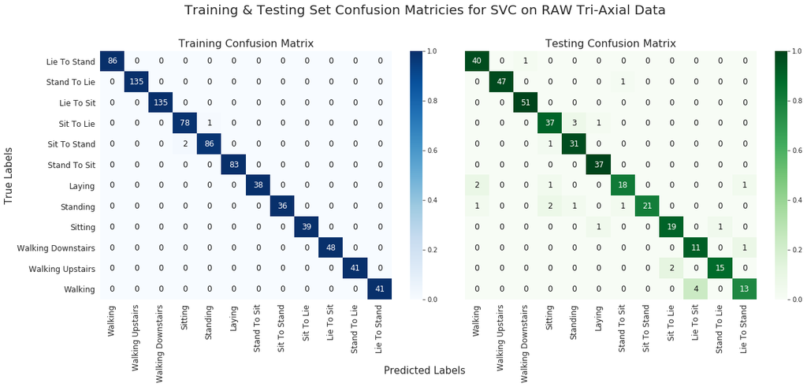

```python
# Plotting Tuned SVC Training & Testing CMs
title = 'Training & Testing Set Confusion Matricies for SVC on RAW Tri-Axial Data'
questionable_annot_colors = ([str(train_output_svc_raw_tuned[2][x, x]) for x in range(12)] +
                             [str(test_output_svc_raw_tuned[2][x, x]) for x in range(12)])
plot_confusion_matricies(train_output_svc_raw_tuned[2],
                         test_output_svc_raw_tuned[2],
                         title, questionable_annot_colors)
```